# week13-unsupervised learning

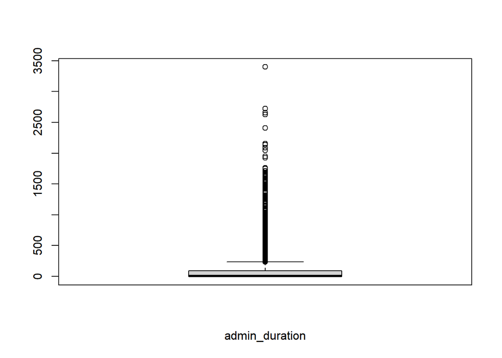

```r
boxplot(data_numeric$Administrative_Duration,xlab="admin_duration")
```

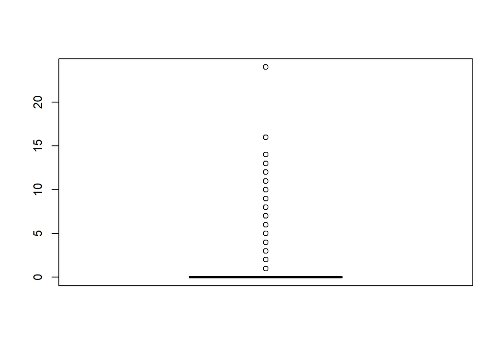

```r
boxplot(data_numeric$Informational,x_lab="informationa")
```

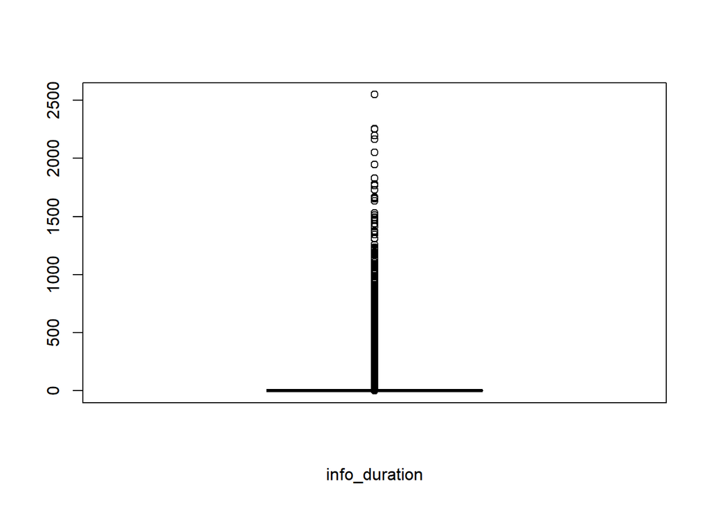

```r
boxplot(data_numeric$Informational_Duration,xlab="info_duration")
```

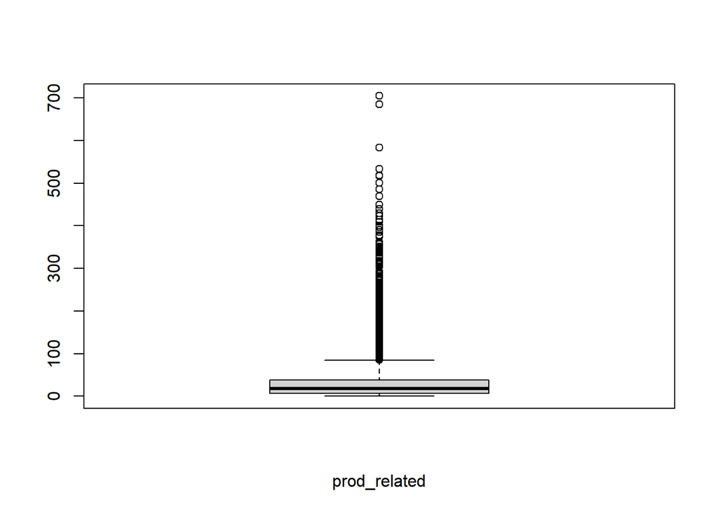

```r
boxplot(data_numeric$ProductRelated,xlab="prod_related")
```

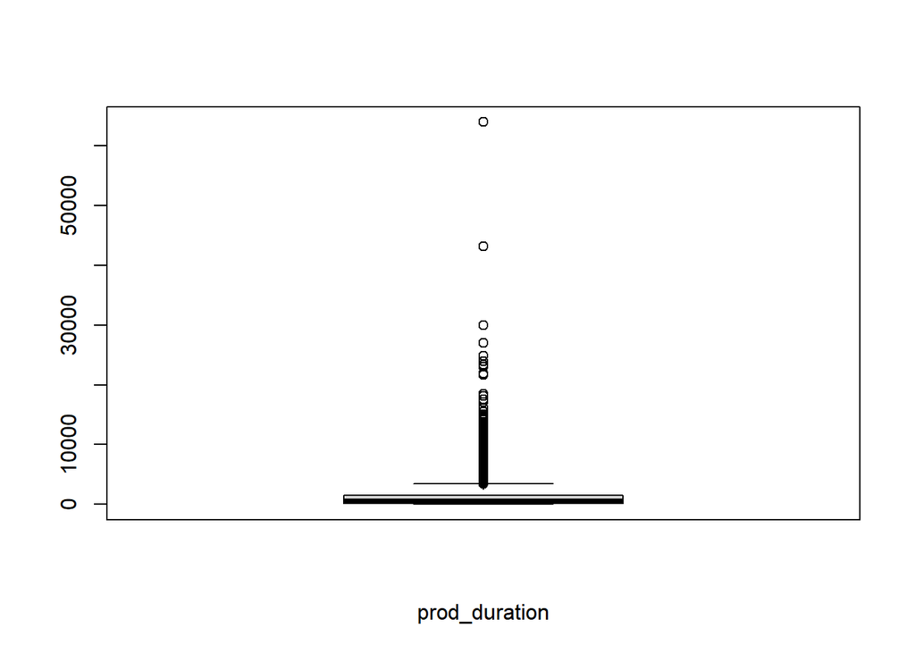

```r
boxplot(data_numeric$ProductRelated_Duration,xlab="prod_duration")
```

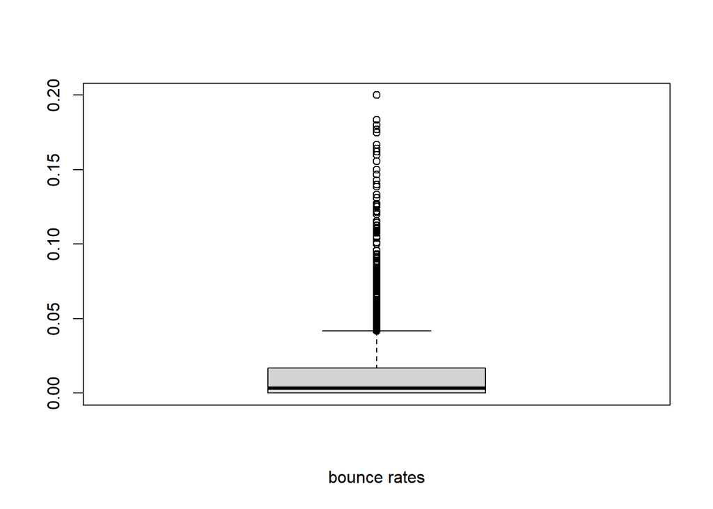

```r
boxplot(data_numeric$BounceRates,xlab="bounce rates")
```

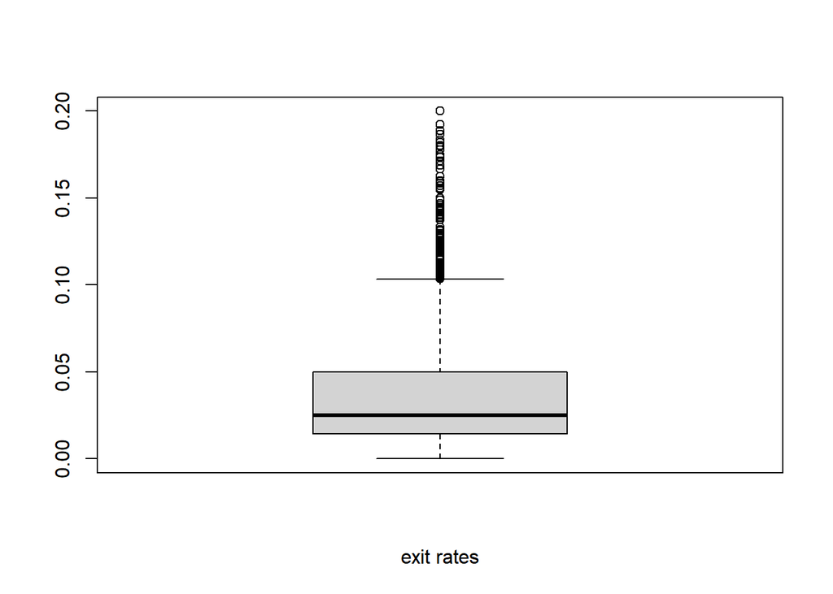

```r
boxplot(data_numeric$ExitRates,xlab="exit rates")
```

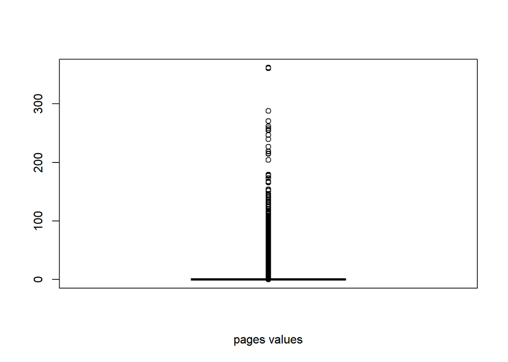

```r
boxplot(data_numeric$PageValues,xlab="pages values")
```

```r
  #our data contain outliers but this could be because of the difference but we wont drop them as this could be source of variation in our data and thus having important info7
```

# Univariate Analysis

**those who generated revenue**

```r
#spliting the data based on revenue since it is the label data set
data_true <- filter(data,Revenue == "TRUE")
summary(data_true)
```

```
##  Administrative   Administrative_Duration Informational
##  Min.   : 0.000   Min.   :   0.00         Min.   : 0.0000
##  1st Qu.: 0.000   1st Qu.:   0.00         1st Qu.: 0.0000
##  Median : 2.000   Median :  52.37         Median : 0.0000
##  Mean   : 3.394   Mean   : 119.48         Mean   : 0.7862
##  3rd Qu.: 5.000   3rd Qu.: 151.08         3rd Qu.: 1.0000
##  Max.   :26.000   Max.   :2086.75         Max.   :12.0000
##  Informational_Duration ProductRelated   ProductRelated_Duration
##  Min.   :   0.00        Min.   :  0.00   Min.   :    0.0
##  1st Qu.:   0.00        1st Qu.: 15.00   1st Qu.:  541.9
##  Median :   0.00        Median : 29.00   Median : 1109.9
##  Mean   :  57.61        Mean   : 48.21   Mean   : 1876.2
##  3rd Qu.:  19.00        3rd Qu.: 57.00   3rd Qu.: 2266.0
##  Max.   :1767.67        Max.   :534.00   Max.   :27009.9
##   BounceRates         ExitRates          PageValues        SpecialDay
##  Min.   :0.000000   Min.   :0.000000   Min.   :  0.000   Min.   :0.00000
##  1st Qu.:0.000000   1st Qu.:0.009521   1st Qu.:  3.641   1st Qu.:0.00000
##  Median :0.000000   Median :0.016000   Median : 16.758   Median :0.00000
##  Mean   :0.005117   Mean   :0.019555   Mean   : 27.265   Mean   :0.02317
##  3rd Qu.:0.006452   3rd Qu.:0.025000   3rd Qu.: 38.898   3rd Qu.:0.00000
##  Max.   :0.200000   Max.   :0.200000   Max.   :361.764   Max.   :1.00000
##     Month           OperatingSystems    Browser           Region
##  Length:1908        Min.   :1.000    Min.   : 1.000   Min.   :1.000
##  Class :character   1st Qu.:2.000    1st Qu.: 2.000   1st Qu.:1.000
##  Mode  :character   Median :2.000    Median : 2.000   Median :2.000
##                     Mean   :2.093    Mean   : 2.453   Mean   :3.082
##                     3rd Qu.:2.000    3rd Qu.: 2.000   3rd Qu.:4.000
##                     Max.   :8.000    Max.   :13.000   Max.   :9.000
##   TrafficType     VisitorType         Weekend        Revenue
##  Min.   : 1.000   Length:1908        Mode :logical   Mode:logical
##  1st Qu.: 2.000   Class :character   FALSE:1409      TRUE:1908
##  Median : 2.000   Mode  :character   TRUE :499
##  Mean   : 4.021
##  3rd Qu.: 4.000
##  Max.   :20.000
```

```r
data_T <- data_true[,c(1:10,12:15)]
desc_stats <- data.frame(
  skewness= apply(data_T, 2, skewness),
  kurtosis = apply(data_T, 2, kurtosis),
  SD = apply(data_T, 2, sd),
  Max = apply(data_T, 2, max),
  var = apply(data_T,2,var),
  mode = apply(data_T,2,getmode)

)
desc_stats <- round(desc_stats, 1)
desc_stats
```

```
##                         skewness kurtosis     SD     Max       var mode
## Administrative               1.5      5.4    3.7    26.0      13.9    0
## Administrative_Duration      4.0     26.1  201.1  2086.8   40447.1    0
## Informational                2.7     12.3    1.5    12.0       2.3    0
## Informational_Duration       5.0     34.1  171.6  1767.7   29453.1    0
## ProductRelated               3.3     18.0   58.3   534.0    3395.1   10
## ProductRelated_Duration      3.3     20.7 2312.2 27009.9 5346335.4    0
## BounceRates                  8.3    112.9    0.0     0.2       0.0    0
## ExitRates                    3.5     28.9    0.0     0.2       0.0    0
## PageValues                   3.2     20.9   35.2   361.8    1238.5    0
## SpecialDay                   5.8     37.4    0.1     1.0       0.0    0
## OperatingSystems             2.6     16.6    0.9     8.0       0.9    2
## Browser                      3.2     14.7    1.9    13.0       3.6    2
## Region                       1.0      3.0    2.4     9.0       5.8    1
## TrafficType                  2.2      8.1    4.0    20.0      15.9    2
```

```r
browser<- data_true$Browser
browser<- table(browser)
browser
```

```
## browser
##    1    2    3    4    5    6    7    8   10   11   12   13
##  365 1223    5  130   86   20    6   21   32    1    3   16
```

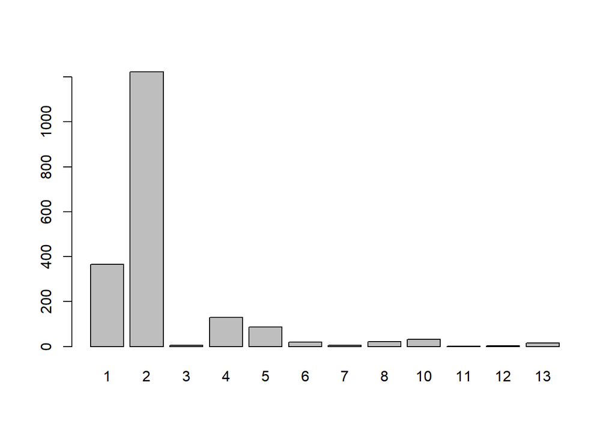

```r
#visualising
barplot(browser)
```

the clients who generated income mostly used browser two

```r
traffic<- data_true$TrafficType
traffic<-table(traffic)
traffic
```

```
## traffic
##   1   2   3   4   5   6   7   8   9  10  11  13  14  16  19  20
## 262 847 180 165  56  53  12  95   4  90  47  43   2   1   1  50
```

the most used traffic type is 2

```r
region<- data_true$Region
region<- table(region)
region
```

```
## region
##   1   2   3   4   5   6   7   8   9
## 771 188 349 175  52 112 119  56  86
```

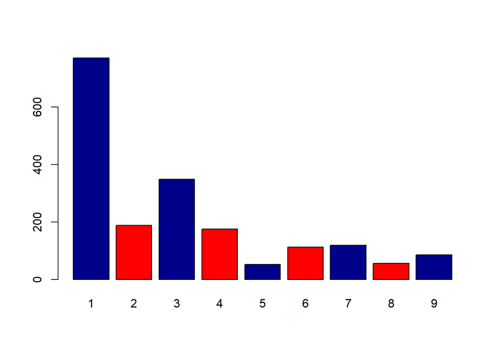

```r
#visualising the regions
barplot(region,col=c("darkblue","red"),)
```

the most clients are from region one

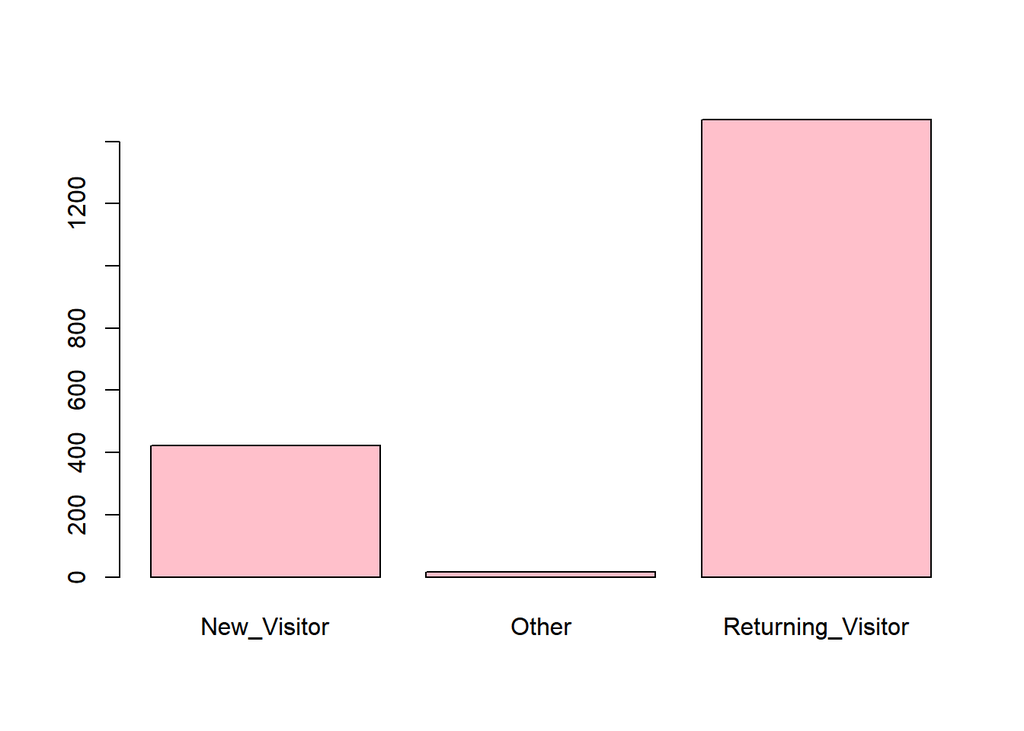

```r
visitors <- data_true$VisitorType
visitors<- table(visitors)
#visualising the visitors
barplot(visitors,col=c("pink"))
```

.the most client who generated revenue are the returning visitors who visits and come later

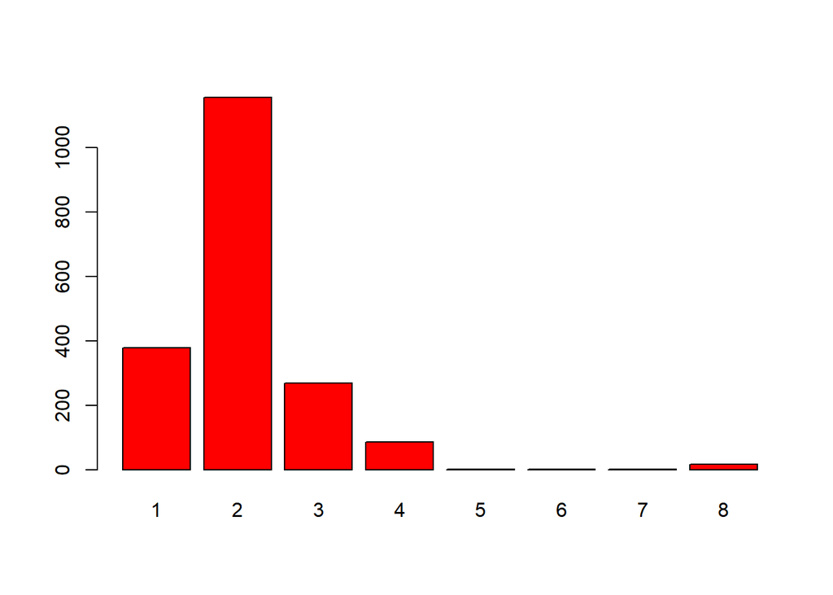

```r
o.s <- data_true$OperatingSystems
o.s<-table(o.s)
#visualising the barplot
barplot(o.s,col=c("red"))
```

the most preffered os was 2 by client who generated revenue

```r
weekend <- data_true$Weekend
weekend<- table(weekend)
weekend
```

```
## weekend
## FALSE  TRUE
##  1409   499
```

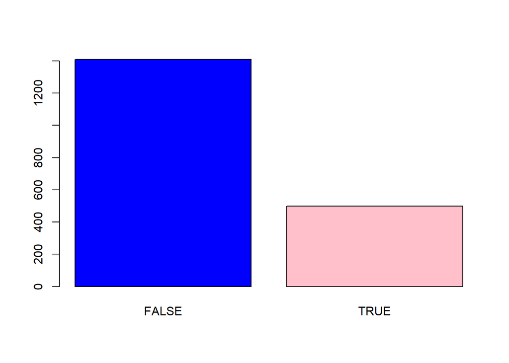

```r
#visualising the weekedn tabke
barplot(weekend,col=c("blue","pink"))
```

most revenue was generated in weekdays

**those who did not generated revenue**

```r
#spliting the data based on revenue since it is the label data set
data_false <- filter(data,Revenue == "FALSE")
summary(data_false)
```

```
##  Administrative   Administrative_Duration Informational
##  Min.   : 0.000   Min.   :  -1.00         Min.   : 0.0000
##  1st Qu.: 0.000   1st Qu.:   0.00         1st Qu.: 0.0000
##  Median : 0.000   Median :   0.00         Median : 0.0000
##  Mean   : 2.121   Mean   :  73.83         Mean   : 0.4522
##  3rd Qu.: 3.000   3rd Qu.:  83.22         3rd Qu.: 0.0000
##  Max.   :27.000   Max.   :3398.75         Max.   :24.0000
##  Informational_Duration ProductRelated   ProductRelated_Duration
##  Min.   :  -1.00        Min.   :  0.00   Min.   :   -1.0
##  1st Qu.:   0.00        1st Qu.:  6.00   1st Qu.:  151.5
##  Median :   0.00        Median : 16.00   Median :  512.2
##  Mean   :  30.27        Mean   : 28.75   Mean   : 1071.3
##  3rd Qu.:   0.00        3rd Qu.: 35.00   3rd Qu.: 1333.1
##  Max.   :2549.38        Max.   :705.00   Max.   :63973.5
##   BounceRates         ExitRates         PageValues        SpecialDay
##  Min.   :0.000000   Min.   :0.00000   Min.   :  0.000   Min.   :0.00000
##  1st Qu.:0.000000   1st Qu.:0.01555   1st Qu.:  0.000   1st Qu.:0.00000
##  Median :0.004255   Median :0.02857   Median :  0.000   Median :0.00000
##  Mean   :0.025275   Mean   :0.04730   Mean   :  1.979   Mean   :0.06852
##  3rd Qu.:0.020000   3rd Qu.:0.05385   3rd Qu.:  0.000   3rd Qu.:0.00000
##  Max.   :0.200000   Max.   :0.20000   Max.   :246.759   Max.   :1.00000
##     Month           OperatingSystems    Browser          Region
##  Length:10408       Min.   :1.00     Min.   : 1.00   Min.   :1.00
##  Class :character   1st Qu.:2.00     1st Qu.: 2.00   1st Qu.:1.00
##  Mode  :character   Median :2.00     Median : 2.00   Median :3.00
##                     Mean   :2.13     Mean   : 2.34   Mean   :3.16
##                     3rd Qu.:3.00     3rd Qu.: 2.00   3rd Qu.:4.00
##                     Max.   :8.00     Max.   :13.00   Max.   :9.00
##   TrafficType     VisitorType         Weekend         Revenue
##  Min.   : 1.000   Length:10408       Mode :logical   Mode :logical
##  1st Qu.: 2.000   Class :character   FALSE:8042      FALSE:10408
##  Median : 2.000   Mode  :character   TRUE :2366
##  Mean   : 4.079
##  3rd Qu.: 4.000
##  Max.   :20.000
```

```r
data_F <- data_false[,c(1:10,12:15)]
desc_stats <- data.frame(
  skewness= apply(data_F, 2, skewness),
  kurtosis = apply(data_F, 2, kurtosis),
  SD = apply(data_F, 2, sd),
  Max = apply(data_F, 2, max),
  var = apply(data_F,2,var),
  mode = apply(data_F,2,getmode)

)
desc_stats <- round(desc_stats, 1)
desc_stats
```

```
##                         skewness kurtosis     SD     Max       var mode
## Administrative               2.1      8.5    3.2    27.0      10.3  0.0
## Administrative_Duration      6.1     63.0  171.1  3398.8   29279.9  0.0
## Informational                4.4     36.9    1.2    24.0       1.5  0.0
## Informational_Duration       8.4     97.2  134.0  2549.4   17954.9  0.0
## ProductRelated               4.7     41.8   40.8   705.0    1661.5  1.0
## ProductRelated_Duration      8.8    199.9 1804.6 63973.5 3256682.7  0.0
## BounceRates                  2.7      9.0    0.1     0.2       0.0  0.0
## ExitRates                    1.9      6.0    0.1     0.2       0.0  0.2
## PageValues                   9.6    150.8    9.1   246.8      82.4  0.0
## SpecialDay                   3.1     11.4    0.2     1.0       0.0  0.0
## OperatingSystems             2.0     12.8    0.9     8.0       0.8  2.0
## Browser                      3.2     15.8    1.7    13.0       2.8  2.0
## Region                       1.0      2.8    2.4     9.0       5.8  1.0
## TrafficType                  1.9      6.2    4.0    20.0      16.3  2.0
```

```r
browser<- data_false$Browser
browser<- table(browser)
browser
```

```
## browser
##    1    2    3    4    5    6    7    8    9   10   11   12   13
## 2094 6728  100  605  381  154   43  114    1  131    5    7   45
```

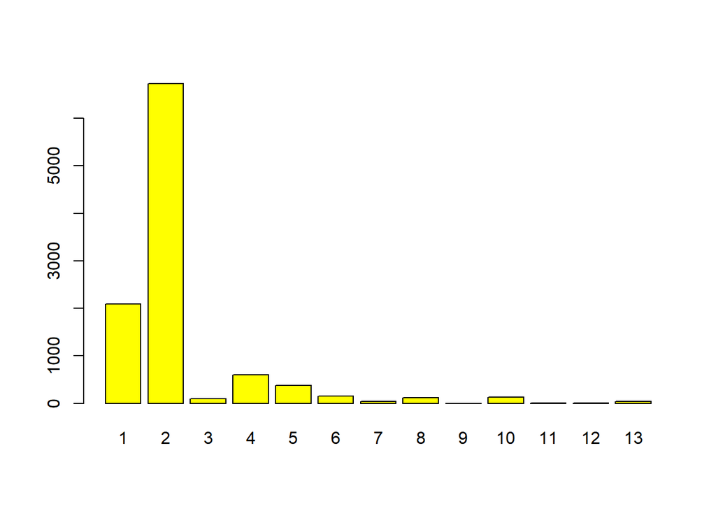

```r
#visualising
barplot(browser,col=c("yellow"))
```

the most used browser by those who did nit generate revenue is 2

```r
traffic<- data_false$TrafficType
traffic<-table(traffic)
traffic
```

```
## traffic
##    1    2    3    4    5    6    7    8    9   10   11   12   13   14   15   16
## 2182 3062 1871  904  204  391   28  248   38  360  200    1  694   11   37    2
##   17   18   19   20
##    1   10   16  148
```

the most preferred trafic by those who donot generate ibcome is 2

```r
region<- data_false$Region
region<- table(region)
region
```

```
## region
##    1    2    3    4    5    6    7    8    9
## 4003  946 2053 1004  265  692  642  378  425
```

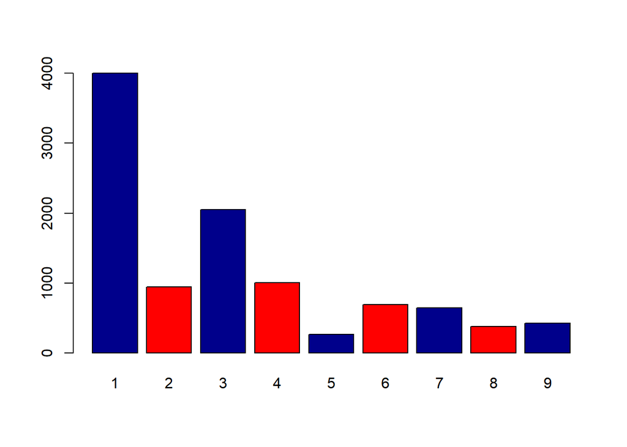

```r
#visualising the regions
barplot(region,col=c("darkblue","red"),)
```

most clients who did not generate income are from region 1

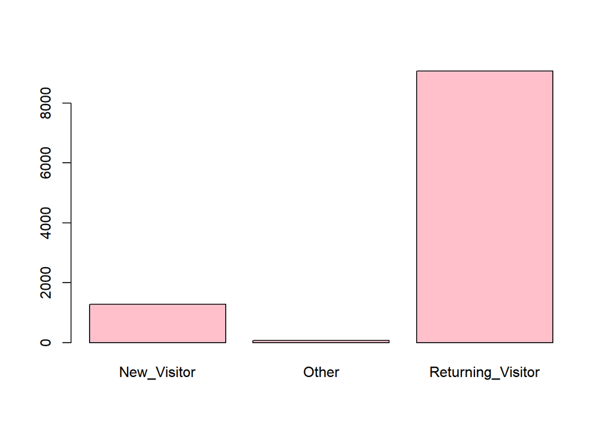

```r
visitors <- data_false$VisitorType
visitors<- table(visitors)
#visualising the visitors
barplot(visitors,col=c("pink"))
```

most visitors who did not generate reenue are the returning visitors

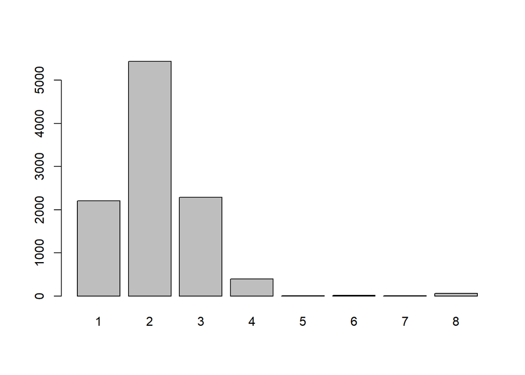

```r
o.s <- data_false$OperatingSystems
o.s<-table(o.s)
#visualising the barplot
barplot(o.s)
```

most preferred os is type 2

```r
weekend <- data_false$Weekend
weekend<- table(weekend)
weekend
```

```
## weekend
## FALSE  TRUE
##  8042  2366
```

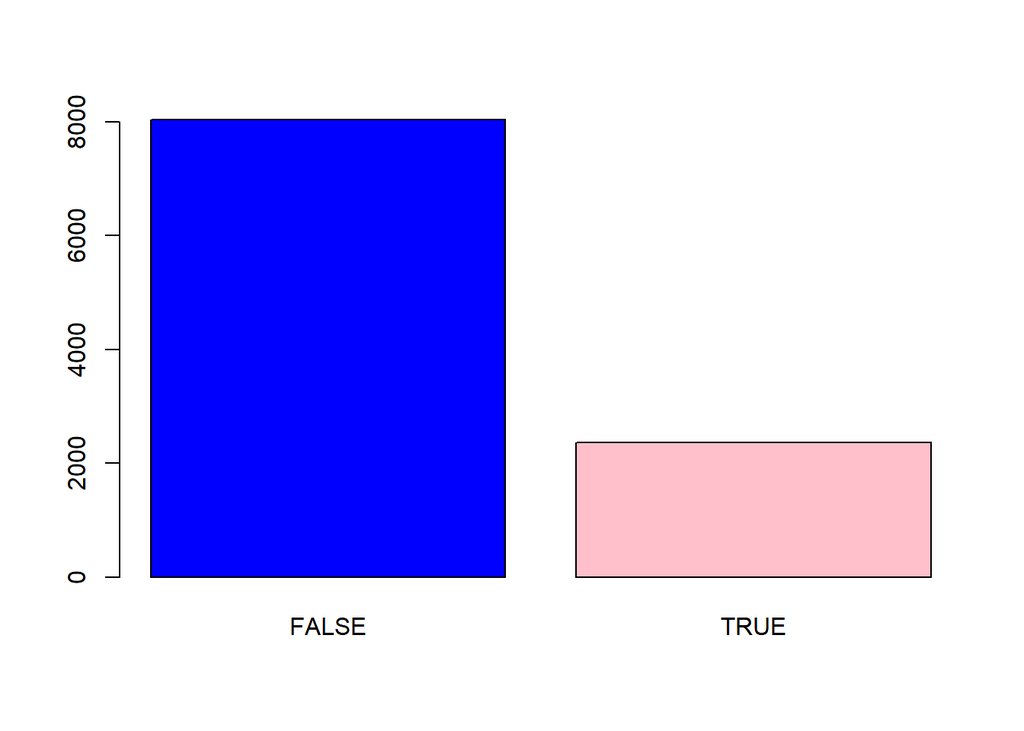

```r
#visualising the weekedn tabke
barplot(weekend,col=c("blue","pink"))
```

# Bivariate Analysis

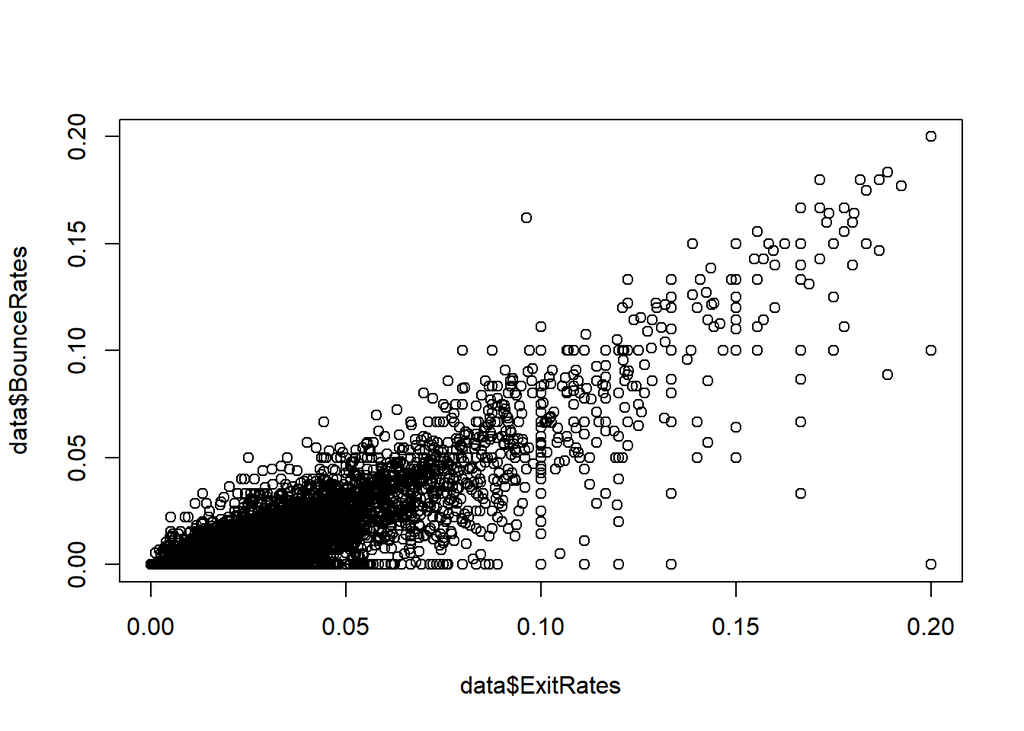

```r
#relationshiop between bounce rate and ad exit rate
plot(data$ExitRates,data$BounceRates)
```

```r
cor(data$ExitRates,data$BounceRates)
```

```
## [1] 0.9134364
```

the exit rates and bounce rate has strongh positive correlation since as one increase he other one also increases

```r
table(data$Revenue,data$Month)
```

```
##
##          Aug  Dec  Feb  Jul June  Mar  May  Nov  Oct  Sep
##   FALSE  357 1511  181  366  259 1702 2998 2238  434  362
##   TRUE    76  216    3   66   29  192  365  760  115   86
```

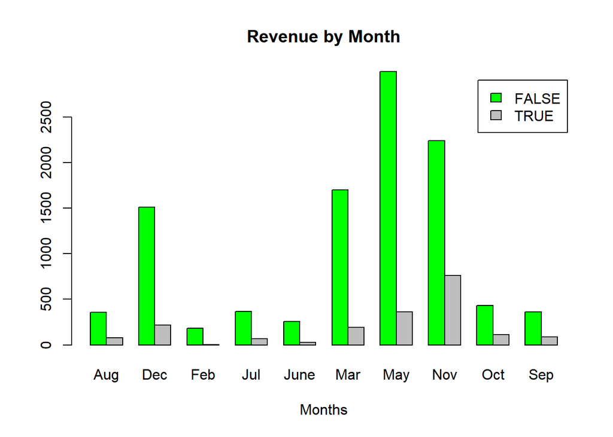

```r
#visualising the revenue and month
revenue <- with(data, table(Revenue , Month))
barplot(revenue,legend=TRUE, beside = TRUE,col=c("green","grey"),
        main = "Revenue by Month",xlab = "Months")
```

month of nov had the leading revenue and may was the leading month when revenue was not genarated

```r
#relationship between revenue and operating system

table(data$Revenue,data$OperatingSystems)
```

```
##
##            1    2    3    4    5    6    7    8
##   FALSE 2203 5438 2284  393    5   17    6   62
##   TRUE   379 1155  268   85    1    2    1   17
```

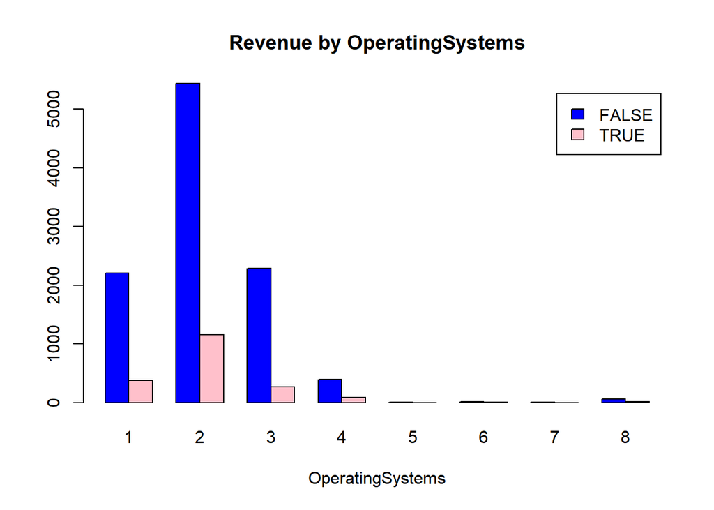

```r
#visualising the revenue and month
revenue <- with(data, table(Revenue ,OperatingSystems ))
barplot(revenue,legend=TRUE, beside = TRUE,col=c("blue","pink"),
        main = "Revenue by OperatingSystems",xlab = "OperatingSystems")
```

os 2 was the one mostly used

```r
#relationship between revenue and visitors type

table(data$Revenue,data$VisitorType)
```

```
##
##         New_Visitor Other Returning_Visitor
##   FALSE        1272    69              9067
##   TRUE          422    16              1470
```

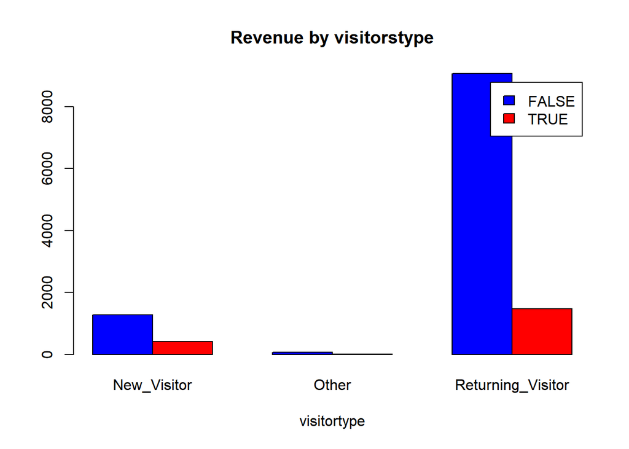

```r
#visualising the revenue and month
revenue <- with(data, table(Revenue ,VisitorType ))
barplot(revenue,legend=TRUE, beside = TRUE,col=c("blue","red"),
        main = "Revenue by visitorstype",xlab = "visitortype")
```

the leading type of customers were the returnung ones

```r
#relationship between revenue and broiwser

table(data$Revenue,data$Browser)
```

```
##
##            1    2    3    4    5    6    7    8    9   10   11   12   13
##   FALSE 2094 6728  100  605  381  154   43  114    1  131    5    7   45
##   TRUE   365 1223    5  130   86   20    6   21    0   32    1    3   16
```

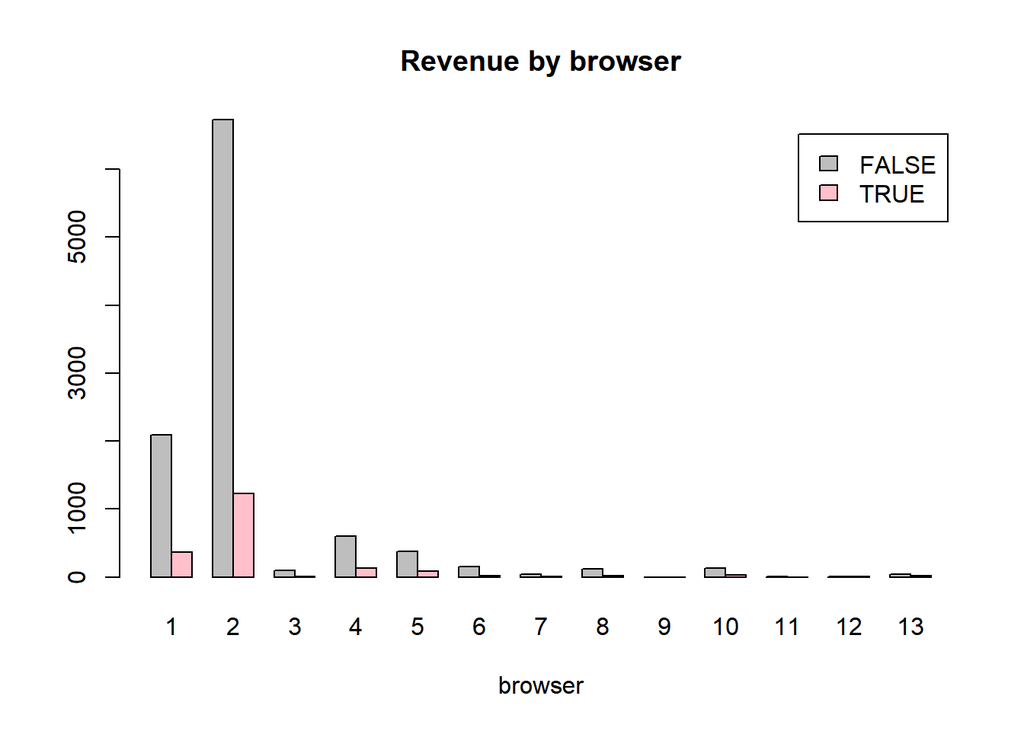

```r
#visualising the revenue and month
revenue <- with(data, table(Revenue ,Browser ))
barplot(revenue,legend=TRUE, beside = TRUE,col=c("grey","pink"),
        main = "Revenue by browser",xlab = "browser")
```

the most prefered browser was 2

```r
#relationship between revenue and region

table(data$Revenue,data$Region)
```

```
##
##            1    2    3    4    5    6    7    8    9
##   FALSE 4003  946 2053 1004  265  692  642  378  425
##   TRUE   771  188  349  175   52  112  119   56   86
```

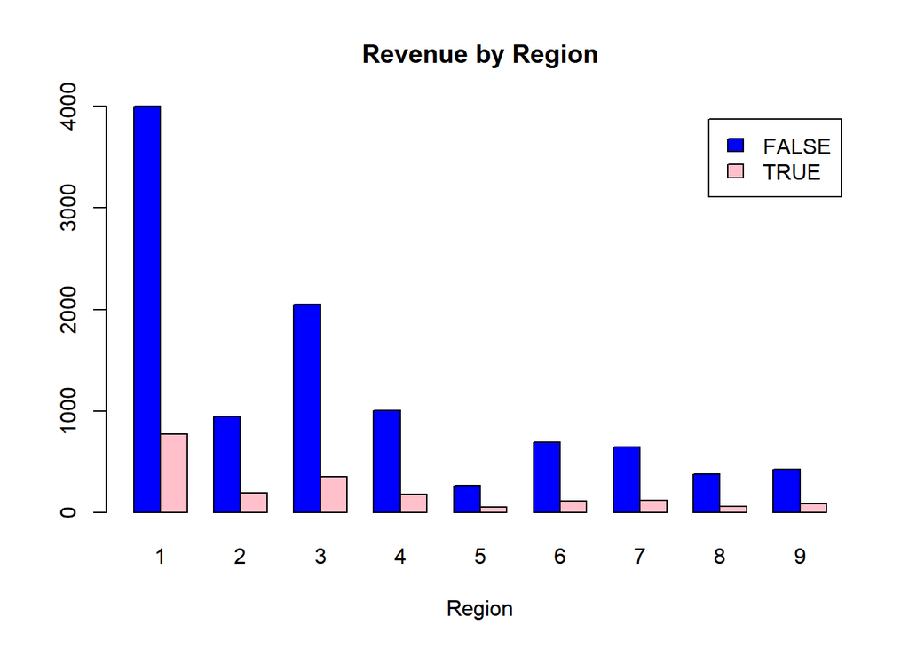

```r
#visualising the revenue and month
region <- with(data, table(Revenue ,Region ))
barplot(region,legend=TRUE, beside = TRUE,col=c("blue","pink"),
        main = "Revenue by Region",xlab = "Region")
```

refion one had the leading clients

```r
#relationship between revenue and traffic

traffic<-table(data$Revenue,data$TrafficType)
traffic
```

```
##
##            1    2    3    4    5    6    7    8    9   10   11   12   13   14
##   FALSE 2182 3062 1871  904  204  391   28  248   38  360  200    1  694   11
##   TRUE   262  847  180  165   56   53   12   95    4   90   47    0   43    2
##
##           15   16   17   18   19   20
##   FALSE   37    2    1   10   16  148
##   TRUE     0    1    0    0    1   50
```

the leading traffic was 2

```r
#converting the categorical data into numeric
library(caret)

dmy <- dummyVars(" ~ .", data = data, fullRank = T)
data_df <- data.frame(predict(dmy, newdata = data))

head(data_df)
```

```
##   Administrative Administrative_Duration Informational Informational_Duration
## 1              0                       0             0                      0
## 2              0                       0             0                      0
## 3              0                      -1             0                     -1
## 4              0                       0             0                      0
## 5              0                       0             0                      0
## 6              0                       0             0                      0
##   ProductRelated ProductRelated_Duration BounceRates ExitRates PageValues
## 1              1                0.000000  0.20000000 0.2000000          0
## 2              2               64.000000  0.00000000 0.1000000          0
## 3              1               -1.000000  0.20000000 0.2000000          0
## 4              2                2.666667  0.05000000 0.1400000          0
## 5             10              627.500000  0.02000000 0.0500000          0
## 6             19              154.216667  0.01578947 0.0245614          0
##   SpecialDay MonthDec MonthFeb MonthJul MonthJune MonthMar MonthMay MonthNov
```

[output cut: 20 more lines]

# Data processing

**dropping revenue column**

```r
#we drop the revenue column since it is the label
df<- data_df[,-c(27)]
head(df)
```

```
##   Administrative Administrative_Duration Informational Informational_Duration
## 1              0                       0             0                      0
## 2              0                       0             0                      0
## 3              0                      -1             0                     -1
## 4              0                       0             0                      0
## 5              0                       0             0                      0
## 6              0                       0             0                      0
##   ProductRelated ProductRelated_Duration BounceRates ExitRates PageValues
## 1              1                0.000000  0.20000000 0.2000000          0
## 2              2               64.000000  0.00000000 0.1000000          0
## 3              1               -1.000000  0.20000000 0.2000000          0
## 4              2                2.666667  0.05000000 0.1400000          0
## 5             10              627.500000  0.02000000 0.0500000          0
## 6             19              154.216667  0.01578947 0.0245614          0
##   SpecialDay MonthDec MonthFeb MonthJul MonthJune MonthMar MonthMay MonthNov
```

[output cut: 20 more lines]

**data scaling**

```r
df<- scale(df)
head(df)
```

```
##   Administrative Administrative_Duration Informational Informational_Duration
## 1     -0.6975533              -0.4574578    -0.3966145             -0.2450294
## 2     -0.6975533              -0.4574578    -0.3966145             -0.2450294
## 3     -0.6975533              -0.4631119    -0.3966145             -0.2521304
## 4     -0.6975533              -0.4574578    -0.3966145             -0.2450294
## 5     -0.6975533              -0.4574578    -0.3966145             -0.2450294
## 6     -0.6975533              -0.4574578    -0.3966145             -0.2450294
##   ProductRelated ProductRelated_Duration BounceRates  ExitRates PageValues
## 1     -0.6914734              -0.6247671  3.67247746  3.2352400 -0.3173633
## 2     -0.6689966              -0.5913358 -0.45743910  1.1745443 -0.3173633
## 3     -0.6914734              -0.6252895  3.67247746  3.2352400 -0.3173633
## 4     -0.6689966              -0.6233742  0.57504004  1.9988226 -0.3173633
## 5     -0.4891823              -0.2969835 -0.04444744  0.1441964 -0.3173633
## 6     -0.2868911              -0.5442099 -0.13139305 -0.3800157 -0.3173633
##   SpecialDay   MonthDec MonthFeb   MonthJul  MonthJune   MonthMar   MonthMay
```

[output cut: 20 more lines]

# Kmeans

K-means clustering is a type of unsupervised learning, which is used when you have unlabeled data (i.e., data without defined categories or groups). The goal of this algorithm is to find groups in the data, with the number of groups represented by the variable K. The algorithm works iteratively to assign each data point to one of K groups based on the features that are provided. Data points are clustered based on feature similarityr

```r
#determine number of clusters using elbow method
wss <- 0

# For 1 to 15 cluster centers
for (i in 1:15) {
  km.out <- kmeans(df, centers = i, nstart = 25)
  # Save total within sum of squares to wss variable
  wss[i] <- km.out$tot.withinss
}
```

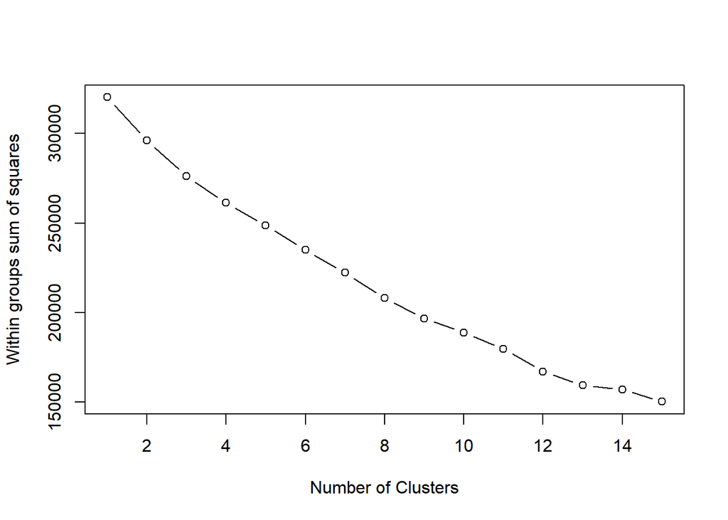

```r
#plot a scree plot

plot(1:15, wss, type = "b",
     xlab = "Number of Clusters",
     ylab = "Within groups sum of squares")
```

```r
#from the screeplot we can see the optimum number of clusters is 12 since that is where the elbow shape formed
#but since we already have the number of clusters in the label column we are are going to use k as 2
```

```r
#performing clustering with the optimal number of clusters
k_means <- kmeans(df, 2,nstart = 25)
# Checking the cluster centers of each variable
k_means$centers
```

```
##   Administrative Administrative_Duration Informational Informational_Duration
## 1     -0.2643168               -0.218585    -0.2548166             -0.1970737
## 2      1.4302829                1.182817     1.3788749              1.0664139
##   ProductRelated ProductRelated_Duration BounceRates   ExitRates  PageValues
## 1     -0.2490363              -0.2324862  0.06048897  0.08979065 -0.04126209
## 2      1.3475962               1.2580393 -0.32732057 -0.48587915  0.22327923
##    SpecialDay    MonthDec    MonthFeb     MonthJul     MonthJune    MonthMar
## 1  0.03274166  0.01035339  0.01958583  0.003859721  0.0005863152  0.03131111
## 2 -0.17717309 -0.05602474 -0.10598371 -0.020885892 -0.0031726946 -0.16943207
##      MonthMay    MonthNov    MonthOct     MonthSep OperatingSystems     Browser
## 1  0.03725527 -0.06531549 -0.02068188 -0.006228759      0.003956135  0.01539390
## 2 -0.20159735  0.35343804  0.11191471  0.033705337     -0.021407610 -0.08330016
##        Region TrafficType VisitorTypeOther VisitorTypeReturning_Visitor
## 1  0.01242819  0.02171321       0.01191922                  -0.04473516
## 2 -0.06725198 -0.11749547      -0.06449783                   0.24207289
##    WeekendTRUE
## 1 -0.009591931
## 2  0.051904279
```

```r
# Previewing the size of observations in each cluster
k_means$size
```

```
## [1] 10395  1921
```

```r
## Our cluster centers (means)
k_means$centers
```

```
##   Administrative Administrative_Duration Informational Informational_Duration
## 1     -0.2643168               -0.218585    -0.2548166             -0.1970737
## 2      1.4302829                1.182817     1.3788749              1.0664139
##   ProductRelated ProductRelated_Duration BounceRates   ExitRates  PageValues
## 1     -0.2490363              -0.2324862  0.06048897  0.08979065 -0.04126209
## 2      1.3475962               1.2580393 -0.32732057 -0.48587915  0.22327923
##    SpecialDay    MonthDec    MonthFeb     MonthJul     MonthJune    MonthMar
## 1  0.03274166  0.01035339  0.01958583  0.003859721  0.0005863152  0.03131111
## 2 -0.17717309 -0.05602474 -0.10598371 -0.020885892 -0.0031726946 -0.16943207
##      MonthMay    MonthNov    MonthOct     MonthSep OperatingSystems     Browser
## 1  0.03725527 -0.06531549 -0.02068188 -0.006228759      0.003956135  0.01539390
## 2 -0.20159735  0.35343804  0.11191471  0.033705337     -0.021407610 -0.08330016
##        Region TrafficType VisitorTypeOther VisitorTypeReturning_Visitor
## 1  0.01242819  0.02171321       0.01191922                  -0.04473516
## 2 -0.06725198 -0.11749547      -0.06449783                   0.24207289
##    WeekendTRUE
## 1 -0.009591931
## 2  0.051904279
```

```r
## Between cluster sum of squares
k_means$betweenss
```

```
## [1] 24171.96
```

```r
## Total cluster sum of squares
k_means$totss
```

```
## [1] 320190
```

```r
#comparing the results of k_means and the real clusters from the revenue column
comp <- table(k_means$cluster)
comp
```

```
##
##     1     2
## 10395  1921
```

```r
comp2<- table(data$Revenue)
comp2
```

```
##
## FALSE  TRUE
## 10408  1908
```

# Hierachial clustering

```r
# Distance matrix using euclidean
d <- dist(df,method = "euclidean")
# Hierarchical clustering using Complete Linkage
res.cls<- hclust(d, method = "complete")
res.cls
```

```
##
## Call:
## hclust(d = d, method = "complete")
##
## Cluster method   : complete
## Distance         : euclidean
## Number of objects: 12316
```

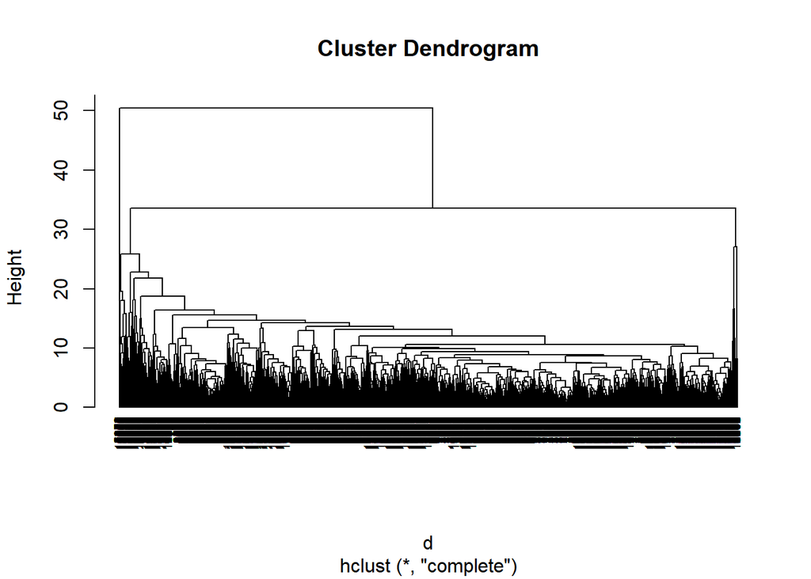

```r
# Plot the obtained dendrogram
plot(res.cls, cex = 0.6, hang = -1)
```

```r
#using cut tree to get the two clusters
cutree(res.cls,k=2)
```

[output not shown]

[output cut: 1881 more lines]

##COMPARISON

##KMEANS CLUSTERING K-means clustering is a machine learning clustering technique used to simplify large datasets into smaller and simple datasets. Distinct patterns are evaluated and similar data sets are grouped together. The variable K represents the number of groups in the data. This article evaluates the pros and cons of the K-means clustering algorithm to help you weigh the benefits of using this clustering technique.

**Pros** 1. Simple: It is easy to implement k-means and identify unknown groups of data from complex data sets. The results are presented in an easy and simple manner.

2. Flexible: K-means algorithm can easily adjust to the changes. If there are any problems, adjusting the cluster segment will allow changes to easily occur on the algorithm.
3. Suitable in a large dataset: K-means is suitable for a large number of datasets and it’s computed much faster than the smaller dataset. It can also produce higher clusters.
4. Efficient: The algorithm used is good at segmenting the large data set. Its efficiency depends on the shape of the clusters. K-means works well in hyper-spherical clusters.
5. Time complexity: K-means segmentation is linear in the number of data objects thus increasing execution time. It doesn’t take more time in classifying similar characteristics in data like hierarchical algorithms.
6. Easy to interpret: The results are easy to interpret. It generates cluster descriptions in a form minimized to ease understanding of the data.
7. Computation cost: Compared to using other clustering methods, a k-means clustering technique is fast and efficient in terms of its computational cost O(K*n*d).
8. Accuracy: K-means analysis improves clustering accuracy and ensures information about a particular problem domain is available. Modification of the k-means algorithm based on this information improves the accuracy of the clusters.

**Cons**

1. NoNo-optimal set of clusters: K-means doesn’t allow the development of an optimal set of clusters and for effective results, you should decide on the clusters before.
2. Lacks consistency: K-means clustering gives varying results on different runs of an algorithm. A random choice of cluster patterns yields different clustering results resulting in inconsistency.
3. Uniform effect: It produces clusters with uniform sizes even when the input data has different sizes.
4. Order of values: The way in which data is ordered in building the algorithm affects the final results of the data set.
5. Sensitivity to scale: Changing or rescaling the dataset either through normalization or standardization will completely change the final results.
6. Crash computer: When dealing with a large dataset, conducting a dendrogram technique will crash the computer due to a lot of computational load and Ram limits.
7. Handle numerical data: K-means algorithm can be performed in numerical data only.

##HIERARCHICAL CLUSTERING

Hierarchical clustering works by treating each observation as a separate cluster. Then, it repeatedly executes the following two steps: (1) identify the two clusters that are closest together, and (2) merge the two most similar clusters. This iterative process continues until all the clusters are merged together.

##Pros:##

-We do not need to specify the number of clusters required for the algorithm. -Hierarchical clustering outputs a hierarchy, ie a structure that is more informative than the unstructured set of flat clusters returned by k-means. -It is also easy to implement.

**Cons

-There is no mathematical objective for Hierarchical clustering. -All the approaches to calculate the similarity between clusters has its own disadvantages. -High space and time complexity for Hierarchical clustering. Hence this clustering algorithm cannot be used when we have huge data.